# L17 — Evaluative Exercise 2

Block 2 · Probability · In-class exercise

# The data

`L17_transactions.csv` records 12,000 card transactions collected over sixty days by a payment processor, 200 on each day. Each transaction was audited afterwards, so its true status is known; independently of the audit, an automatic detector had raised, or not raised, an alert at the moment of payment.

| Column | Meaning |
| --- | --- |
| `txn_id` | Identifier of the transaction |
| `day` | Day of the window, 1 to 60 |
| `minute` | Minute of the day at which the payment was made, 0 to 1439 |
| `weekend` | Whether the day was a weekend day |
| `channel` | `web` (online), `app` (mobile app) or `pos` (card terminal in a shop) |
| `amount` | Amount of the transaction, in euros |
| `fraud` | 1 if the audit found the transaction fraudulent |
| `alert` | 1 if the detector raised an alert |

Throughout, one transaction is drawn at random from the 12,000. The exercises use five events:

| Event | The transaction… | In the file |
| --- | --- | --- |
| $F$ | is fraudulent | `fraud == 1` |
| $A$ | raised an alert | `alert == 1` |
| $W$ | came from the web channel | `channel == "web"` |
| $S$ | came from a card terminal in a shop | `channel == "pos"` |
| $E$ | occurred on a weekend day | `weekend == "yes"` |

$F^c$ and $A^c$ are the complements of $F$ and $A$: the transaction is honest, no alert was raised. The prevalence of fraud is $\pi = P(F)$.

The detector was certified on a separate set, where it was found that $P(A \mid F) = 0.92$ (sensitivity) and $P(A^c \mid F^c) = 0.97$ (specificity).

Four exercises. Fill the chunks; the questions that close each one are there for you to check your own understanding, and are not handed in.

```r
tx <- read.csv("L17_transactions.csv", stringsAsFactors = FALSE)

str(tx)
```

```
## 'data.frame':    12000 obs. of  8 variables:
##  $ txn_id : chr  "T00001" "T00002" "T00003" "T00004" ...
##  $ day    : int  1 1 1 1 1 1 1 1 1 1 ...
##  $ minute : int  226 595 935 1212 153 191 598 371 948 628 ...
##  $ weekend: chr  "no" "no" "no" "no" ...
##  $ channel: chr  "web" "web" "app" "app" ...
##  $ amount : num  65.7 39.5 41.2 18.6 40.1 ...
##  $ fraud  : int  0 0 0 0 0 0 0 0 0 0 ...
##  $ alert  : int  0 0 0 0 0 0 0 0 0 0 ...
```

# 1 Exercise 1 — Conditioning and independence

Estimate probabilities by relative frequencies in the file.

1. Compute $P(A)$ and the conditional probabilities $P(A \mid W)$ and $P(A \mid S)$.
2. Check the product rule on two pairs of events: compare $P(A \cap W)$ with $P(A)\,P(W)$, and $P(A \cap E)$ with $P(A)\,P(E)$. For each pair compute the difference between the two, and the same difference as a percentage of the product — for the first pair, $100\,[P(A \cap W) - P(A)P(W)] \,/\, [P(A)P(W)]$.

```r
# Validate the supplied portfolio without altering it.
stopifnot(nrow(tx) == 12000, ncol(tx) == 8, !anyNA(tx),
          identical(sort(unique(tx$day)), 1:60), all(table(tx$day) == 200),
          sum(tx$fraud) == 189, sum(tx$alert) == 545,
          all(tx$fraud %in% 0:1), all(tx$alert %in% 0:1))
print(data.frame(Transactions = nrow(tx), Variables = ncol(tx),
                 Days = length(unique(tx$day)), Transactions_per_day = 200,
                 Missing_values = sum(is.na(tx)), Frauds = sum(tx$fraud),
                 Alerts = sum(tx$alert)), row.names = FALSE)
```

```
##  Transactions Variables Days Transactions_per_day Missing_values Frauds Alerts
##         12000         8   60                  200              0    189    545
```

```r
# 1. Each conditional probability uses only its conditioning group.
A <- tx$alert == 1
W <- tx$channel == "web"
S <- tx$channel == "pos"
E <- tx$weekend == "yes"
p_A <- mean(A)
print(data.frame(Probability = c("P(A)", "P(A | W)", "P(A | S)"),
                 Numerator = c(sum(A), sum(A & W), sum(A & S)),
                 Denominator = c(nrow(tx), sum(W), sum(S)),
                 Value = c(p_A, mean(A[W]), mean(A[S]))),
      row.names = FALSE, digits = 8)
```

```
##  Probability Numerator Denominator       Value
##         P(A)       545       12000 0.045416667
##     P(A | W)       265        5432 0.048784978
##     P(A | S)        71        1775 0.040000000
```

```r
# 2. The professor's percentage formula uses the signed difference.
intersection <- c(mean(A & W), mean(A & E))
product <- c(p_A * mean(W), p_A * mean(E))
difference <- intersection - product
print(data.frame(Pair = c("A and W", "A and E"),
                 Intersection_probability = intersection,
                 Product_of_marginals = product,
                 Signed_difference = difference,
                 Absolute_difference = abs(difference),
                 Percentage_difference = 100 * difference / product),
      row.names = FALSE, digits = 8)
```

```
##     Pair Intersection_probability Product_of_marginals Signed_difference
##  A and W              0.022083333          0.020558611     0.00152472222
##  A and E              0.011250000          0.012111111    -0.00086111111
##  Absolute_difference Percentage_difference
##        0.00152472222             7.4164651
##        0.00086111111            -7.1100917
```

```r
# Empirical differences alone do not establish population dependence.
```

> **(a)** One of the two differences is the smaller. Is it still the smaller once each is expressed as a percentage of its own product?

> **(b)** Neither pair satisfies the product rule exactly. Does that prove that $A$ and $E$ are dependent? If not, what would be needed to decide?

# 2 Exercise 2 — Bayes’ theorem and the diagnostic quantities

1. Build the 2×2 table of `fraud` by `alert`. From it estimate the sensitivity, the specificity and the prevalence $\pi$ on this portfolio, compare the first two with the certified 0.92 and 0.97, and count the false alarms and the frauds that raised no alert.
2. Using the **certified** values and the prevalence you have just estimated, compute $P(A)$ from the law of total probability
   $$P(A) =
   P(A \mid F)P(F) + P(A \mid F^c)P(F^c),$$
   where $P(A \mid F^c) = 1 - 0.97$ and $P(F^c) = 1 - \pi$, and then the positive predictive value $P(F \mid A)$ from Bayes’ theorem. Compare it with the value read directly off the table.

```r
# 1. Rows are audit status; columns are detector alert status.
tab <- table(fraud = factor(tx$fraud, levels = 0:1),
             alert = factor(tx$alert, levels = 0:1))
print(tab)
```

```
##      alert
## fraud     0     1
##     0 11443   368
##     1    12   177
```

```r
TP <- unname(tab["1", "1"])
TN <- unname(tab["0", "0"])
FP <- unname(tab["0", "1"])
FN <- unname(tab["1", "0"])
print(data.frame(True_positives = TP, True_negatives = TN,
                 False_alarms_FP = FP, Frauds_without_alert_FN = FN),
      row.names = FALSE)
```

```
##  True_positives True_negatives False_alarms_FP Frauds_without_alert_FN
##             177          11443             368                      12
```

```r
sensitivity_observed <- TP / (TP + FN)
specificity_observed <- TN / (TN + FP)
prevalence <- (TP + FN) / sum(tab)
sensitivity_certified <- 0.92
specificity_certified <- 0.97
print(data.frame(Quantity = c("Sensitivity: P(A | F)",
                             "Specificity: P(no alert | no fraud)"),
                 Observed = c(sensitivity_observed, specificity_observed),
                 Certified = c(sensitivity_certified, specificity_certified),
                 Observed_minus_certified =
                   c(sensitivity_observed - sensitivity_certified,
                     specificity_observed - specificity_certified)),
      row.names = FALSE, digits = 8)
```

```
##                             Quantity   Observed Certified
##                Sensitivity: P(A | F) 0.93650794      0.92
##  Specificity: P(no alert | no fraud) 0.96884260      0.97
##  Observed_minus_certified
##              0.0165079365
##             -0.0011573956
```

```r
cat(sprintf("Observed fraud prevalence P(F) = %d / %d = %.8f\n",
            TP + FN, sum(tab), prevalence))
```

```
## Observed fraud prevalence P(F) = 189 / 12000 = 0.01575000
```

```r
# 2. Only this model calculation uses the certified detector rates.
p_A_certified <- sensitivity_certified * prevalence +
  (1 - specificity_certified) * (1 - prevalence)
ppv_certified <- sensitivity_certified * prevalence / p_A_certified
ppv_empirical <- TP / (TP + FP)
print(data.frame(Basis = c("Certified rates + observed prevalence",
                          "Empirical contingency table"),
                 Alert_probability = c(p_A_certified, mean(A)),
                 Positive_predictive_value = c(ppv_certified, ppv_empirical)),
      row.names = FALSE, digits = 8)
```

```
##                                  Basis Alert_probability
##  Certified rates + observed prevalence       0.044017500
##            Empirical contingency table       0.045416667
##  Positive_predictive_value
##                 0.32918726
##                 0.32477064
```

```r
cat(sprintf("Empirical PPV minus certified-model PPV = %.8f\n",
            ppv_empirical - ppv_certified))
```

```
## Empirical PPV minus certified-model PPV = -0.00441661
```

> **(a)** State in words the difference between $P(A \mid F)$ and $P(F \mid A)$, and give both numbers.

> **(b)** Using the counts of point 1, explain why the false alarms outnumber the true ones.

# 3 Exercise 3 — Two discrete models, and a continuous one

1. Let $X$ be the number of fraudulent transactions among 200 independent ones, each fraudulent with probability $\pi$ (the prevalence estimated above). Give the distribution of $X$, compute $P(X = 0)$ and $P(X \le 2)$ with `dbinom` and `pbinom` and $E(X)$ and $\mathrm{Var}(X)$ from their formulas; then recompute the two probabilities under the Poisson model with the same mean, $200\pi$, and compare.
2. Count the alerts raised on each of the sixty days, `tapply(tx$alert, tx$day, sum)`, and compute their mean and variance.
3. Let $T$ be the waiting time in minutes between one alert and the next within a day. The observed waiting times are extracted by

   ```r
   gap <- c()
   for (d in 1:60) {
     minutes <- sort(tx$minute[tx$alert == 1 & tx$day == d])
     gap    <- c(gap, diff(minutes))
   }
   ```

   Compute the mean $\bar t$ and the standard deviation of `gap`, and estimate the rate of the exponential, in alerts per minute, by $\hat\lambda = 1/\bar t$. Then estimate $P(T > 100)$ and $P(T > 200 \mid T > 100)$ by relative frequencies among the gaps, and compute the model value $e^{-100\hat\lambda}$.

```r
# 1. Under the stated independent, constant-prevalence model:
# X ~ Binomial(200, prevalence); Poisson(200 * prevalence) approximates it.
n_transactions <- 200
lambda_count <- n_transactions * prevalence
binomial_prob <- c(dbinom(0, size = n_transactions, prob = prevalence),
                   pbinom(2, size = n_transactions, prob = prevalence))
poisson_prob <- c(dpois(0, lambda = lambda_count),
                  ppois(2, lambda = lambda_count))
print(data.frame(Quantity = c("E(X) = n*pi", "Var(X) = n*pi*(1-pi)",
                             "Poisson lambda = n*pi"),
                 Value = c(lambda_count, lambda_count * (1 - prevalence),
                           lambda_count)), row.names = FALSE, digits = 8)
```

```
##               Quantity     Value
##            E(X) = n*pi 3.1500000
##   Var(X) = n*pi*(1-pi) 3.1003875
##  Poisson lambda = n*pi 3.1500000
```

```r
print(data.frame(Probability = c("P(X = 0)", "P(X <= 2)"),
                 Binomial = binomial_prob, Poisson = poisson_prob,
                 Poisson_minus_Binomial = poisson_prob - binomial_prob),
      row.names = FALSE, digits = 8)
```

```
##  Probability    Binomial     Poisson Poisson_minus_Binomial
##     P(X = 0) 0.041791186 0.042852127           0.0010609412
##    P(X <= 2) 0.388495060 0.390436441           0.0019413808
```

```r
# 2. Keep all sixty daily counts visible.
daily_alerts <- tapply(tx$alert, tx$day, sum)
print(daily_alerts)
```

```
##  1  2  3  4  5  6  7  8  9 10 11 12 13 14 15 16 17 18 19 20 21 22 23 24 25 26
##  9 12 14 13 13 10 10  9 11  6  6  8  6 10 11  4  9  5 12  4  7 12 10  5  8 12
## 27 28 29 30 31 32 33 34 35 36 37 38 39 40 41 42 43 44 45 46 47 48 49 50 51 52
##  7  7 12 11 13  4 11 13  8 11 10 12  9 16 15  5 10  9 11  6  7 12  7  8  7  5
## 53 54 55 56 57 58 59 60
##  7  7  6  8 15  6  6  8
```

```r
daily_mean <- mean(daily_alerts)
daily_variance <- var(daily_alerts)
print(data.frame(Mean_daily_alerts = daily_mean,
                 Variance_daily_alerts = daily_variance,
                 Variance_to_mean = daily_variance / daily_mean),
      row.names = FALSE, digits = 8)
```

```
##  Mean_daily_alerts Variance_daily_alerts Variance_to_mean
##          9.0833333             9.1963277        1.0124397
```

```r
cat(sprintf(paste0("Daily variance is %.3f times the mean; a Poisson model ",
                   "has equal mean and variance. This descriptive comparison ",
                   "does not verify the complete model.\n"),
            daily_variance / daily_mean))
```

```
## Daily variance is 1.012 times the mean; a Poisson model has equal mean and variance. This descriptive comparison does not verify the complete model.
```

```r
# 3. Use the supplied loop exactly; no gaps cross day boundaries.
gap <- c()
for (d in 1:60) {
  minutes <- sort(tx$minute[tx$alert == 1 & tx$day == d])
  gap    <- c(gap, diff(minutes))
}
mean_gap <- mean(gap)
sd_gap <- sd(gap)
lambda_gap <- 1 / mean_gap
p_gt100 <- mean(gap > 100)
# The conditioning denominator counts only gaps already exceeding 100.
p_gt200_given100 <- sum(gap > 200) / sum(gap > 100)
exponential_100 <- exp(-100 * lambda_gap)
print(data.frame(Number_of_gaps = length(gap), Mean_minutes = mean_gap,
                 SD_minutes = sd_gap, Rate_per_minute = lambda_gap),
      row.names = FALSE, digits = 8)
```

```
##  Number_of_gaps Mean_minutes SD_minutes Rate_per_minute
##             485    139.91959  132.52522    0.0071469622
```

```r
print(data.frame(Quantity = c("Empirical P(T > 100)",
                             "Empirical P(T > 200 | T > 100)",
                             "Exponential exp(-100 * lambda)"),
                 Value = c(p_gt100, p_gt200_given100, exponential_100),
                 Difference_from_exponential =
                   c(p_gt100 - exponential_100,
                     p_gt200_given100 - exponential_100, 0)),
      row.names = FALSE, digits = 8)
```

```
##                        Quantity      Value Difference_from_exponential
##            Empirical P(T > 100) 0.49484536                0.0055046183
##  Empirical P(T > 200 | T > 100) 0.53750000                0.0481592575
##  Exponential exp(-100 * lambda) 0.48934074                0.0000000000
```

```r
cat(sprintf("Conditional calculation: %d / %d gaps.\n",
            sum(gap > 200), sum(gap > 100)))
```

```
## Conditional calculation: 129 / 240 gaps.
```

```r
cat(sprintf(paste0("The empirical probabilities differ from the fitted ",
                   "exponential value by %.4f and %.4f. Within-day gaps omit ",
                   "day-boundary intervals; %d zero-minute gap(s) reflect ",
                   "minute-level ties. These comparisons do not establish ",
                   "an exact continuous exponential model.\n"),
            p_gt100 - exponential_100,
            p_gt200_given100 - exponential_100, sum(gap == 0)))
```

```
## The empirical probabilities differ from the fitted exponential value by 0.0055 and 0.0482. Within-day gaps omit day-boundary intervals; 1 zero-minute gap(s) reflect minute-level ties. These comparisons do not establish an exact continuous exponential model.
```

> **(a)** Which of the Binomial and the Poisson is the exact distribution of $X$, and under what conditions is the other a good approximation to it?

> **(b)** Which property of the Poisson do the mean and the variance of the daily counts support?

> **(c)** The three quantities of point 3 are close to one another. Which property of the exponential distribution does that illustrate, and what does it mean for an operator who has already waited 100 minutes?

# 4 Exercise 4 — Sampling distribution of the mean

Treat the 12,000 transactions as the population, so that $\mu$ and $\sigma$ of `amount` are known parameters rather than estimates.

1. Compute $\mu$, $\sigma$, the median and the skewness $\frac{1}{N}\sum_i \big((y_i - \mu)/\sigma\big)^3$, where $y_1, \dots, y_N$ are the $N = 12{,}000$ amounts. Take $\sigma$ from `sd()`: with $N$ this large its divisor $N - 1$ makes no visible difference.
2. For $n = 5$, $n = 30$ and $n = 100$, draw 2000 samples and keep the mean of each — `replicate(2000, mean(sample(tx$amount, 5)))` — and compare the standard deviation of the 2000 means with $\sigma/\sqrt{n}$. Draw the four histograms together with `par(mfrow = c(2, 2))`: the amounts, and the means for the three sample sizes.
3. Let $\hat{\pi}$ be the proportion of fraudulent transactions in a random sample of $n$ of the 12,000, whose prevalence $\pi$ is known. Compute the standard error $\sqrt{\pi(1-\pi)/n}$ for $n = 200$ and $n = 1000$, and check the conditions $n\pi \ge 10$ and $n(1-\pi) \ge 10$ in both cases.

```r
# 1. Use sd() and the specified standardized third moment.
mu <- mean(tx$amount)
sigma <- sd(tx$amount)
amount_median <- median(tx$amount)
amount_skewness <- mean(((tx$amount - mu) / sigma)^3)
print(data.frame(Mean_EUR = mu, SD_EUR = sigma, Median_EUR = amount_median,
                 Skewness = amount_skewness), row.names = FALSE, digits = 8)
```

```
##   Mean_EUR    SD_EUR Median_EUR  Skewness
##  48.526159 61.526697      29.39 4.7279261
```

```r
# 2. sample() defaults to sampling without replacement, as in the example.
set.seed(1717)
sample_sizes <- c(5, 30, 100)
sample_means <- lapply(sample_sizes, function(n) {
  replicate(2000, mean(sample(tx$amount, n)))
})
names(sample_means) <- paste0("n", sample_sizes)
simulation <- data.frame(
  Sample_size = sample_sizes,
  Repetitions = 2000,
  Mean_of_sample_means = vapply(sample_means, mean, numeric(1)),
  Empirical_SD = vapply(sample_means, sd, numeric(1)),
  Theoretical_SE = sigma / sqrt(sample_sizes)
)
simulation$SD_minus_theoretical <- simulation$Empirical_SD -
  simulation$Theoretical_SE
simulation$SD_relative_difference_percent <-
  100 * simulation$SD_minus_theoretical / simulation$Theoretical_SE
print(simulation, row.names = FALSE, digits = 8)
```

```
##  Sample_size Repetitions Mean_of_sample_means Empirical_SD Theoretical_SE
##            5        2000            47.336936   26.3559523     27.5155755
##           30        2000            47.834338   10.7950947     11.2331867
##          100        2000            48.672867    6.1690141      6.1526697
##  SD_minus_theoretical SD_relative_difference_percent
##           -1.15962324                    -4.21442482
##           -0.43809201                    -3.89997981
##            0.01634438                     0.26564696
```

```r
cat(paste0("The table compares simulated SDs with the requested sigma/sqrt(n). ",
           "Monte Carlo variation is expected. Sampling without replacement ",
           "also gives a small finite-population adjustment: multiply this SE ",
           "by sqrt(1 - n/12000), because sigma was computed with sd().\n"))
```

```
## The table compares simulated SDs with the requested sigma/sqrt(n). Monte Carlo variation is expected. Sampling without replacement also gives a small finite-population adjustment: multiply this SE by sqrt(1 - n/12000), because sigma was computed with sd().
```

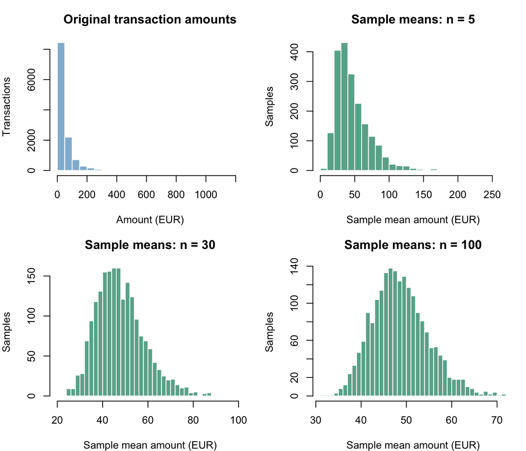

```r
old_par <- par(no.readonly = TRUE)
par(mfrow = c(2, 2))
par(mar = c(4, 4, 3, 1))
hist(tx$amount, breaks = 30, col = "#91B9D6", border = "white",
     main = "Original transaction amounts", xlab = "Amount (EUR)",
     ylab = "Transactions")
for (i in seq_along(sample_sizes)) {
  hist(sample_means[[i]], breaks = 30, col = "#6AAE99", border = "white",
       main = paste("Sample means: n =", sample_sizes[i]),
       xlab = "Sample mean amount (EUR)", ylab = "Samples")
}
```

```r
par(old_par)

# 3. Check each Normal-approximation condition separately.
proportion_n <- c(200, 1000)
proportion_checks <- data.frame(
  Sample_size = proportion_n,
  Fraud_prevalence = prevalence,
  SE_proportion = sqrt(prevalence * (1 - prevalence) / proportion_n),
  n_pi = proportion_n * prevalence,
  n_one_minus_pi = proportion_n * (1 - prevalence)
)
proportion_checks$Fraud_condition_ge10 <- proportion_checks$n_pi >= 10
proportion_checks$Nonfraud_condition_ge10 <-
  proportion_checks$n_one_minus_pi >= 10
proportion_checks$Both_conditions_satisfied <-
  proportion_checks$Fraud_condition_ge10 &
  proportion_checks$Nonfraud_condition_ge10
print(proportion_checks, row.names = FALSE, digits = 8)
```

```
##  Sample_size Fraud_prevalence SE_proportion  n_pi n_one_minus_pi
##          200          0.01575  0.0088039586  3.15         196.85
##         1000          0.01575  0.0039372500 15.75         984.25
##  Fraud_condition_ge10 Nonfraud_condition_ge10 Both_conditions_satisfied
##                 FALSE                    TRUE                     FALSE
##                  TRUE                    TRUE                      TRUE
```

> **(a)** How does the standard deviation of the sample means behave as $n$ goes from 5 to 100, and what law does that follow?

> **(b)** At $n = 5$ the means are still visibly skewed. Is that consistent with the Central Limit Theorem?

> **(c)** For which of the two sample sizes of point 3 is the Normal approximation to $\hat{\pi}$ admissible, and what would you use for the other?